# Part I - (Dataset Exploration of The Loan Data From Prosper)

## by (Osasenaga Oriakhi)

## Introduction

> This data set is called the Loan Data from Prosper.It contains 113,937 loans with 81 variables on each loan.It contains details about the borrowers' employment status,whether or not their income can be verified,whether or not they own homes,whether or not they have taken a Prosper loan before,their credit score range,their occupation,the purpose of the loan, etc. The variables also include the loan amount, borrower rate (or interest rate), current loan status, borrower income, and many others.

## Preliminary Wrangling

```python
# import all packages and set plots to be embedded inline
import numpy as np
import pandas as pd
import matplotlib.pyplot as plt
import seaborn as sb

%matplotlib inline
```

```python
pd.set_option('display.max_columns',None)
```

```python
sb.set(font_scale=1.3)
```

```python
#load in dataset
loan=pd.read_csv('prosperLoanData.csv')
loan.head()
```

|  | ListingKey | ListingNumber | ListingCreationDate | CreditGrade | Term | LoanStatus | ClosedDate | BorrowerAPR | BorrowerRate | LenderYield | EstimatedEffectiveYield | EstimatedLoss | EstimatedReturn | ProsperRating (numeric) | ProsperRating (Alpha) | ProsperScore | ListingCategory (numeric) | BorrowerState | Occupation | EmploymentStatus | EmploymentStatusDuration | IsBorrowerHomeowner | CurrentlyInGroup | GroupKey | DateCreditPulled | CreditScoreRangeLower | CreditScoreRangeUpper | FirstRecordedCreditLine | CurrentCreditLines | … |
| --- | --- | --- | --- | --- | --- | --- | --- | --- | --- | --- | --- | --- | --- | --- | --- | --- | --- | --- | --- | --- | --- | --- | --- | --- | --- | --- | --- | --- | --- | --- |
| 0 | 1021339766868145413AB3B | 193129 | 2007-08-26 19:09:29.263000000 | C | 36 | Completed | 2009-08-14 00:00:00 | 0.16516 | 0.1580 | 0.1380 | NaN | NaN | NaN | NaN | NaN | NaN | 0 | CO | Other | Self-employed | 2.0 | True | True | NaN | 2007-08-26 18:41:46.780000000 | 640.0 | 659.0 | 2001-10-11 00:00:00 | 5.0 | … |
| 1 | 10273602499503308B223C1 | 1209647 | 2014-02-27 08:28:07.900000000 | NaN | 36 | Current | NaN | 0.12016 | 0.0920 | 0.0820 | 0.07960 | 0.0249 | 0.05470 | 6.0 | A | 7.0 | 2 | CO | Professional | Employed | 44.0 | False | False | NaN | 2014-02-27 08:28:14 | 680.0 | 699.0 | 1996-03-18 00:00:00 | 14.0 | … |
| 2 | 0EE9337825851032864889A | 81716 | 2007-01-05 15:00:47.090000000 | HR | 36 | Completed | 2009-12-17 00:00:00 | 0.28269 | 0.2750 | 0.2400 | NaN | NaN | NaN | NaN | NaN | NaN | 0 | GA | Other | Not available | NaN | False | True | 783C3371218786870A73D20 | 2007-01-02 14:09:10.060000000 | 480.0 | 499.0 | 2002-07-27 00:00:00 | NaN | … |
| 3 | 0EF5356002482715299901A | 658116 | 2012-10-22 11:02:35.010000000 | NaN | 36 | Current | NaN | 0.12528 | 0.0974 | 0.0874 | 0.08490 | 0.0249 | 0.06000 | 6.0 | A | 9.0 | 16 | GA | Skilled Labor | Employed | 113.0 | True | False | NaN | 2012-10-22 11:02:32 | 800.0 | 819.0 | 1983-02-28 00:00:00 | 5.0 | … |
| 4 | 0F023589499656230C5E3E2 | 909464 | 2013-09-14 18:38:39.097000000 | NaN | 36 | Current | NaN | 0.24614 | 0.2085 | 0.1985 | 0.18316 | 0.0925 | 0.09066 | 3.0 | D | 4.0 | 2 | MN | Executive | Employed | 44.0 | True | False | NaN | 2013-09-14 18:38:44 | 680.0 | 699.0 | 2004-02-20 00:00:00 | 19.0 | … |

```python
#assess data
print(loan.shape)
print(loan.info())
```

```
(113937, 81)
<class 'pandas.core.frame.DataFrame'>
RangeIndex: 113937 entries, 0 to 113936
Data columns (total 81 columns):
ListingKey                             113937 non-null object
ListingNumber                          113937 non-null int64
ListingCreationDate                    113937 non-null object
CreditGrade                            28953 non-null object
Term                                   113937 non-null int64
LoanStatus                             113937 non-null object
ClosedDate                             55089 non-null object
BorrowerAPR                            113912 non-null float64
BorrowerRate                           113937 non-null float64
LenderYield                            113937 non-null float64
EstimatedEffectiveYield                84853 non-null float64
EstimatedLoss                          84853 non-null float64
EstimatedReturn                        84853 non-null float64
ProsperRating (numeric)                84853 non-null float64
ProsperRating (Alpha)                  84853 non-null object
ProsperScore                           84853 non-null float64
ListingCategory (numeric)              113937 non-null int64
BorrowerState                          108422 non-null object
Occupation                             110349 non-null object
EmploymentStatus                       111682 non-null object
EmploymentStatusDuration               106312 non-null float64
IsBorrowerHomeowner                    113937 non-null bool
CurrentlyInGroup                       113937 non-null bool
GroupKey                               13341 non-null object
DateCreditPulled                       113937 non-null object
CreditScoreRangeLower                  113346 non-null float64
CreditScoreRangeUpper                  113346 non-null float64
FirstRecordedCreditLine                113240 non-null object
CurrentCreditLines                     106333 non-null float64
OpenCreditLines                        106333 non-null float64
TotalCreditLinespast7years             113240 non-null float64
OpenRevolvingAccounts                  113937 non-null int64
OpenRevolvingMonthlyPayment            113937 non-null float64
InquiriesLast6Months                   113240 non-null float64
TotalInquiries                         112778 non-null float64
CurrentDelinquencies                   113240 non-null float64
```

[output cut: 33 more lines]

```
LP_CustomerPrincipalPayments           113937 non-null float64
LP_InterestandFees                     113937 non-null float64
LP_ServiceFees                         113937 non-null float64
LP_CollectionFees                      113937 non-null float64
LP_GrossPrincipalLoss                  113937 non-null float64
LP_NetPrincipalLoss                    113937 non-null float64
LP_NonPrincipalRecoverypayments        113937 non-null float64
PercentFunded                          113937 non-null float64
Recommendations                        113937 non-null int64
InvestmentFromFriendsCount             113937 non-null int64
InvestmentFromFriendsAmount            113937 non-null float64
Investors                              113937 non-null int64
dtypes: bool(3), float64(50), int64(11), object(17)
memory usage: 68.1+ MB
None
```

```python
loan.describe()
```

|  | ListingNumber | Term | BorrowerAPR | BorrowerRate | LenderYield | EstimatedEffectiveYield | EstimatedLoss | EstimatedReturn | ProsperRating (numeric) | ProsperScore | ListingCategory (numeric) | EmploymentStatusDuration | CreditScoreRangeLower | CreditScoreRangeUpper | CurrentCreditLines | OpenCreditLines | TotalCreditLinespast7years | OpenRevolvingAccounts | OpenRevolvingMonthlyPayment | InquiriesLast6Months | TotalInquiries | CurrentDelinquencies | AmountDelinquent | DelinquenciesLast7Years | PublicRecordsLast10Years | PublicRecordsLast12Months | RevolvingCreditBalance | BankcardUtilization | AvailableBankcardCredit | … |
| --- | --- | --- | --- | --- | --- | --- | --- | --- | --- | --- | --- | --- | --- | --- | --- | --- | --- | --- | --- | --- | --- | --- | --- | --- | --- | --- | --- | --- | --- | --- |
| count | 1.139370e+05 | 113937.000000 | 113912.000000 | 113937.000000 | 113937.000000 | 84853.000000 | 84853.000000 | 84853.000000 | 84853.000000 | 84853.000000 | 113937.000000 | 106312.000000 | 113346.000000 | 113346.000000 | 106333.000000 | 106333.000000 | 113240.000000 | 113937.00000 | 113937.000000 | 113240.000000 | 112778.000000 | 113240.000000 | 106315.000000 | 112947.000000 | 113240.000000 | 106333.000000 | 1.063330e+05 | 106333.000000 | 106393.000000 | … |
| mean | 6.278857e+05 | 40.830248 | 0.218828 | 0.192764 | 0.182701 | 0.168661 | 0.080306 | 0.096068 | 4.072243 | 5.950067 | 2.774209 | 96.071582 | 685.567731 | 704.567731 | 10.317192 | 9.260164 | 26.754539 | 6.96979 | 398.292161 | 1.435085 | 5.584405 | 0.592052 | 984.507059 | 4.154984 | 0.312646 | 0.015094 | 1.759871e+04 | 0.561309 | 11210.225447 | … |
| std | 3.280762e+05 | 10.436212 | 0.080364 | 0.074818 | 0.074516 | 0.068467 | 0.046764 | 0.030403 | 1.673227 | 2.376501 | 3.996797 | 94.480605 | 66.458275 | 66.458275 | 5.457866 | 5.022644 | 13.637871 | 4.63097 | 447.159711 | 2.437507 | 6.429946 | 1.978707 | 7158.270157 | 10.160216 | 0.727868 | 0.154092 | 3.293640e+04 | 0.317918 | 19818.361309 | … |
| min | 4.000000e+00 | 12.000000 | 0.006530 | 0.000000 | -0.010000 | -0.182700 | 0.004900 | -0.182700 | 1.000000 | 1.000000 | 0.000000 | 0.000000 | 0.000000 | 19.000000 | 0.000000 | 0.000000 | 2.000000 | 0.00000 | 0.000000 | 0.000000 | 0.000000 | 0.000000 | 0.000000 | 0.000000 | 0.000000 | 0.000000 | 0.000000e+00 | 0.000000 | 0.000000 | … |
| 25% | 4.009190e+05 | 36.000000 | 0.156290 | 0.134000 | 0.124200 | 0.115670 | 0.042400 | 0.074080 | 3.000000 | 4.000000 | 1.000000 | 26.000000 | 660.000000 | 679.000000 | 7.000000 | 6.000000 | 17.000000 | 4.00000 | 114.000000 | 0.000000 | 2.000000 | 0.000000 | 0.000000 | 0.000000 | 0.000000 | 0.000000 | 3.121000e+03 | 0.310000 | 880.000000 | … |
| 50% | 6.005540e+05 | 36.000000 | 0.209760 | 0.184000 | 0.173000 | 0.161500 | 0.072400 | 0.091700 | 4.000000 | 6.000000 | 1.000000 | 67.000000 | 680.000000 | 699.000000 | 10.000000 | 9.000000 | 25.000000 | 6.00000 | 271.000000 | 1.000000 | 4.000000 | 0.000000 | 0.000000 | 0.000000 | 0.000000 | 0.000000 | 8.549000e+03 | 0.600000 | 4100.000000 | … |
| 75% | 8.926340e+05 | 36.000000 | 0.283810 | 0.250000 | 0.240000 | 0.224300 | 0.112000 | 0.116600 | 5.000000 | 8.000000 | 3.000000 | 137.000000 | 720.000000 | 739.000000 | 13.000000 | 12.000000 | 35.000000 | 9.00000 | 525.000000 | 2.000000 | 7.000000 | 0.000000 | 0.000000 | 3.000000 | 0.000000 | 0.000000 | 1.952100e+04 | 0.840000 | 13180.000000 | … |
| max | 1.255725e+06 | 60.000000 | 0.512290 | 0.497500 | 0.492500 | 0.319900 | 0.366000 | 0.283700 | 7.000000 | 11.000000 | 20.000000 | 755.000000 | 880.000000 | 899.000000 | 59.000000 | 54.000000 | 136.000000 | 51.00000 | 14985.000000 | 105.000000 | 379.000000 | 83.000000 | 463881.000000 | 99.000000 | 38.000000 | 20.000000 | 1.435667e+06 | 5.950000 | 646285.000000 | … |

```python
#check for duplicate data
sum(loan.duplicated())
```

```
0
```

```python
#check for missing data
loan.isna().sum()
```

```
ListingKey                                  0
ListingNumber                               0
ListingCreationDate                         0
CreditGrade                             84984
Term                                        0
LoanStatus                                  0
ClosedDate                              58848
BorrowerAPR                                25
BorrowerRate                                0
LenderYield                                 0
EstimatedEffectiveYield                 29084
EstimatedLoss                           29084
EstimatedReturn                         29084
ProsperRating (numeric)                 29084
ProsperRating (Alpha)                   29084
ProsperScore                            29084
ListingCategory (numeric)                   0
BorrowerState                            5515
Occupation                               3588
EmploymentStatus                         2255
EmploymentStatusDuration                 7625
IsBorrowerHomeowner                         0
CurrentlyInGroup                            0
GroupKey                               100596
DateCreditPulled                            0
CreditScoreRangeLower                     591
CreditScoreRangeUpper                     591
FirstRecordedCreditLine                   697
CurrentCreditLines                       7604
OpenCreditLines                          7604
                                        ...
TotalProsperLoans                       91852
TotalProsperPaymentsBilled              91852
OnTimeProsperPayments                   91852
ProsperPaymentsLessThanOneMonthLate     91852
ProsperPaymentsOneMonthPlusLate         91852
ProsperPrincipalBorrowed                91852
ProsperPrincipalOutstanding             91852
ScorexChangeAtTimeOfListing             95009
LoanCurrentDaysDelinquent                   0
LoanFirstDefaultedCycleNumber           96985
LoanMonthsSinceOrigination                  0
LoanNumber                                  0
LoanOriginalAmount                          0
LoanOriginationDate                         0
LoanOriginationQuarter                      0
MemberKey                                   0
MonthlyLoanPayment                          0
LP_CustomerPayments                         0
LP_CustomerPrincipalPayments                0
LP_InterestandFees                          0
LP_ServiceFees                              0
LP_CollectionFees                           0
LP_GrossPrincipalLoss                       0
LP_NetPrincipalLoss                         0
LP_NonPrincipalRecoverypayments             0
PercentFunded                               0
Recommendations                             0
InvestmentFromFriendsCount                  0
InvestmentFromFriendsAmount                 0
Investors                                   0
Length: 81, dtype: int64
```

```python
#we will make a cpy of the data before doing a few cleaning
clean_loan=loan.copy()
```

```python
#drop some columns with missing data
clean_loan=clean_loan.drop(columns=['CreditGrade','ClosedDate','EstimatedEffectiveYield','EstimatedLoss','EstimatedReturn',
                                    'ProsperRating (numeric)','ProsperRating (Alpha)','ProsperScore','GroupKey',
                                    'TotalProsperPaymentsBilled','OnTimeProsperPayments','ProsperPaymentsLessThanOneMonthLate',
                                    'ProsperPaymentsOneMonthPlusLate','ProsperPrincipalBorrowed','ProsperPrincipalOutstanding',
                                   'ScorexChangeAtTimeOfListing','LoanFirstDefaultedCycleNumber'])
```

```python
clean_loan.info()
```

```
<class 'pandas.core.frame.DataFrame'>
RangeIndex: 113937 entries, 0 to 113936
Data columns (total 64 columns):
ListingKey                            113937 non-null object
ListingNumber                         113937 non-null int64
ListingCreationDate                   113937 non-null object
Term                                  113937 non-null int64
LoanStatus                            113937 non-null object
BorrowerAPR                           113912 non-null float64
BorrowerRate                          113937 non-null float64
LenderYield                           113937 non-null float64
ListingCategory (numeric)             113937 non-null int64
BorrowerState                         108422 non-null object
Occupation                            110349 non-null object
EmploymentStatus                      111682 non-null object
EmploymentStatusDuration              106312 non-null float64
IsBorrowerHomeowner                   113937 non-null bool
CurrentlyInGroup                      113937 non-null bool
DateCreditPulled                      113937 non-null object
CreditScoreRangeLower                 113346 non-null float64
CreditScoreRangeUpper                 113346 non-null float64
FirstRecordedCreditLine               113240 non-null object
CurrentCreditLines                    106333 non-null float64
OpenCreditLines                       106333 non-null float64
TotalCreditLinespast7years            113240 non-null float64
OpenRevolvingAccounts                 113937 non-null int64
OpenRevolvingMonthlyPayment           113937 non-null float64
InquiriesLast6Months                  113240 non-null float64
TotalInquiries                        112778 non-null float64
CurrentDelinquencies                  113240 non-null float64
AmountDelinquent                      106315 non-null float64
DelinquenciesLast7Years               112947 non-null float64
PublicRecordsLast10Years              113240 non-null float64
PublicRecordsLast12Months             106333 non-null float64
RevolvingCreditBalance                106333 non-null float64
BankcardUtilization                   106333 non-null float64
AvailableBankcardCredit               106393 non-null float64
TotalTrades                           106393 non-null float64
TradesNeverDelinquent (percentage)    106393 non-null float64
TradesOpenedLast6Months               106393 non-null float64
```

[output cut: 14 more lines]

```
LP_CustomerPayments                   113937 non-null float64
LP_CustomerPrincipalPayments          113937 non-null float64
LP_InterestandFees                    113937 non-null float64
LP_ServiceFees                        113937 non-null float64
LP_CollectionFees                     113937 non-null float64
LP_GrossPrincipalLoss                 113937 non-null float64
LP_NetPrincipalLoss                   113937 non-null float64
LP_NonPrincipalRecoverypayments       113937 non-null float64
PercentFunded                         113937 non-null float64
Recommendations                       113937 non-null int64
InvestmentFromFriendsCount            113937 non-null int64
InvestmentFromFriendsAmount           113937 non-null float64
Investors                             113937 non-null int64
dtypes: bool(3), float64(37), int64(11), object(13)
memory usage: 53.4+ MB
```

### What is the structure of your dataset?

> The dataset consist of 113937 entries and 81 columns, only a few of these columns will be used for this exploration and so I have dropped sme f the columns that have missing data and are not necessary for the exploration.The data contains no duplicate data and is missing a number of data of which some have been dropped.

### What is/are the main feature(s) of interest in your dataset?

> I am interested in a few things.First, whether we have more unemployed people taking the loans than employed people,also whether there are more unemployed peple defaulting on the loan payment than employed people, whether people prefer to take longer term loans than shorter term loans.Then, the most common reasons for the loan acquistion, and the relatinship between the borrower's interest rate and the borrower's annual interest rate.Then, I wanted to see the relationship between the borrower's monthly income , whether or not their income is verifiable and the employment status.

### What features in the dataset do you think will help support your investigation into your feature(s) of interest?

> The following features of the datasets will be important for this investigation EmploymentStatus, LoanStatus, Term, BarrowerRate, BorrowerAPR,LoanOriginalAmount,Listingcategory,IsBorrowerHomeowner,TotalProsperLoan,IncomeVerifiable and StatedMonthlyIncome

## Univariate Exploration

# First, the most common reason people acquired the loan?

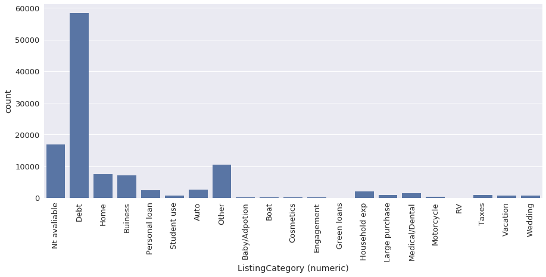

```python
#start by plotting a bar plot
plt.figure(figsize=(15,6))
base_color=sb.color_palette()[0]
g=sb.countplot(data=clean_loan, x='ListingCategory (numeric)', color=base_color)
g.set(xticklabels=['Nt avaliable','Debt','Home','Buiness','Personal loan','Student use',
                   'Auto','Other','Baby/Adpotion','Boat','Cosmetics',
        'Engagement','Green loans','Household exp','Large purchase',
                   'Medical/Dental','Motorcycle','RV','Taxes','Vacation','Wedding']
)
plt.xticks(rotation=90);
```

```python
loan_p=clean_loan['ListingCategory (numeric)'].value_counts().head()
```

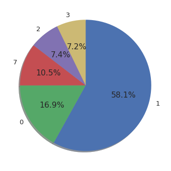

```python
#plot a pie plot to know the exact percentage of the most common reason for the loan
def pie_fxn():
    '''This function is to plot a pie chart,can call it anytime I need to plot a pie plot'''
    plt.figure(figsize=(15,6))
    plt.axis('square')
    plt.pie(loan_p,labels=loan_p.index,
            autopct='%1.1f%%',shadow=True,startangle=90,counterclock=False)
pie_fxn()
```

## Amount of borrowers that are home owners?

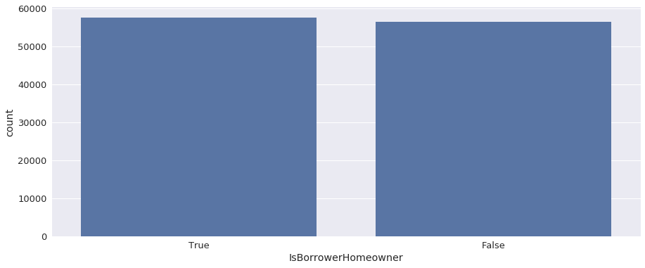

```python
#bar plot to show count of home owners
type_order=clean_loan.IsBorrowerHomeowner.value_counts().index
base_color = sb.color_palette()[0]
plt.figure(figsize=(15,6))
sb.countplot(data=loan, x='IsBorrowerHomeowner', color=base_color, order=type_order);
```

There seem to be no difference in the amount of borrowers who are home owners, I will like to plot a pie chart to know the exact percentage.

```python
loan_h=clean_loan['IsBorrowerHomeowner'].value_counts()
```

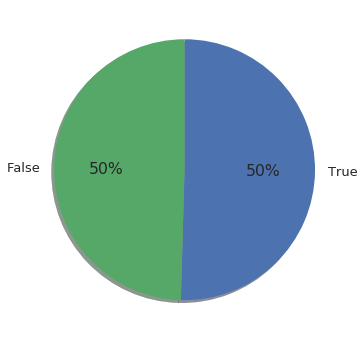

```python
#ppie chart to know exact percentage
def pie_fxn1():
    '''This function is to plot a pie chart,can call it anytime I need to plot a pie plot'''
    plt.figure(figsize=(15,6))
    plt.axis('square')
    plt.pie(loan_h,labels=loan_h.index,
            autopct='%.0f%%',shadow=True,startangle=90,counterclock=False)
pie_fxn1()
```

Just ike I thought the percentage of borrowers who are home owners is the same with borrowers who are not home owners.

# What is the percentage of people that have defaulted in payment?

```python
loan_x=clean_loan['LoanStatus'].value_counts().head(4)
```

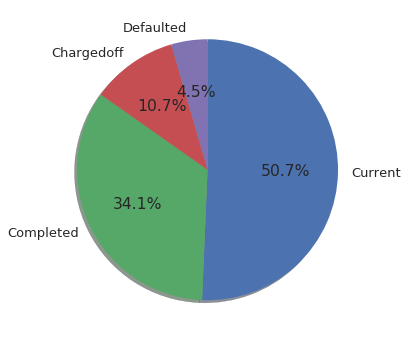

```python
# pie plot for percentage
def pie_fxn2():
    '''This function is to plot a pie chart,can call it anytime I need to plot a pie plot'''
    plt.figure(figsize=(15,6))
    plt.axis('square')
    plt.pie(loan_x,labels=loan_x.index,
            autopct='%1.1f%%',shadow=True,startangle=90,counterclock=False)
pie_fxn2()
```

Only a small amount of the borrowers defaulted in their payment. 4.5% were defaulters.

## What is the most popular loan term?

```python
loan_t=clean_loan['Term'].value_counts()
```

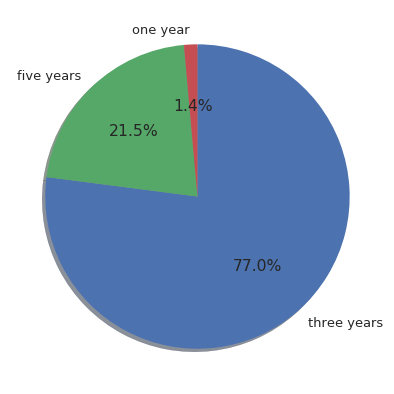

```python
# pie plot for most popular loan term
def pie_fxn3():
    '''This function is to plot a pie chart,can call it anytime I need to plot a pie plot'''
    plt.figure(figsize=(16,7))
    plt.axis('square')
    plt.pie(loan_t,labels=['three years','five years','one year'],
            autopct='%1.1f%%',shadow=True,startangle=90,counterclock=False)
pie_fxn3()
```

Looks like most people(77%) preffered the three years loan term.

# Number of borrowers that have taken out prosper loans before

```python
clean_loan.TotalProsperLoans.value_counts()
```

```
1.0    15538
2.0     4540
3.0     1447
4.0      417
5.0      104
6.0       29
7.0        8
0.0        1
8.0        1
Name: TotalProsperLoans, dtype: int64
```

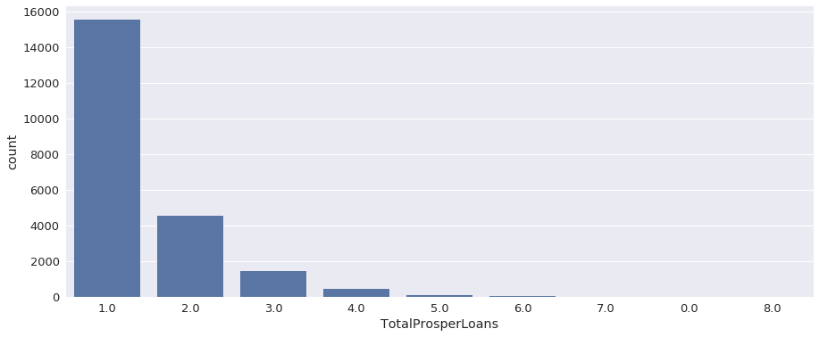

```python
#plot a bar plot
type_order=clean_loan.TotalProsperLoans.value_counts().index
base_color = sb.color_palette()[0]
plt.figure(figsize=(15,6))
sb.countplot(data=clean_loan, x='TotalProsperLoans', color=base_color, order=type_order);
```

From the data avaliable, looks like a large amount of borrowers(about fifteen thousand of the about twenty-two thousand borrowers) are taking the Prosper loan for the first time.

# Number of borrowers that their income can be verified

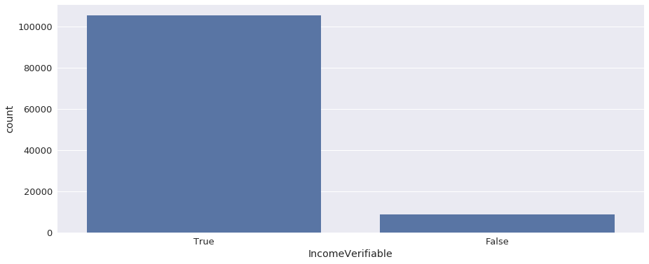

```python
#bar plot to show count of borrowers whose income can be verified
type_order=clean_loan.IncomeVerifiable.value_counts().index
base_color = sb.color_palette()[0]
plt.figure(figsize=(15,6))
sb.countplot(data=clean_loan, x='IncomeVerifiable', color=base_color, order=type_order);
```

```python
income=clean_loan['IncomeVerifiable'].value_counts()
```

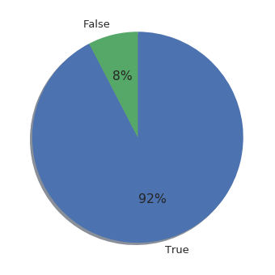

```python
# percentage of borrowers with verifiable income
def pie_fxn4():
    '''This function is to plot a pie chart,can call it anytime I need to plot a pie plot'''
    plt.figure(figsize=(15,6))
    plt.axis('square')
    plt.pie(income,labels=income.index,
            autopct='%.0f%%',shadow=True,startangle=90,counterclock=False)
pie_fxn4()
```

A number of borrowers(92%) have incomes that can be verified.

# Show the distribution of the interest rate

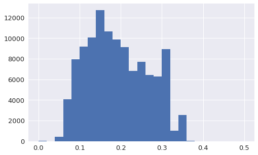

```python
#using a bin width of 0.02
binsize=0.02
bins = np.arange(0, clean_loan['BorrowerRate'].max()+binsize, binsize)
plt.figure(figsize=[8, 5])
plt.hist(data = clean_loan, x = 'BorrowerRate',bins=bins);
```

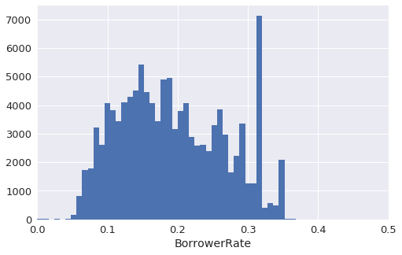

```python
#investigating further on a smaller scale
binsize=0.008
bins = np.arange(0, 0.5, 0.008)
plt.figure(figsize=[8, 5])
plt.hist(data = clean_loan, x = 'BorrowerRate',bins=bins)
plt.xlim([0,0.5])
plt.xlabel('BorrowerRate');
```

# Discuss the distribution(s) of your variable(s) of interest. Were there any unusual points? Did you need to perform any transformations?

# Of the features you investigated, were there any unusual distributions? Did you perform any operations on the data to tidy, adjust, or change the form of the data? If so, why did you do this?

For the first question, I had to replace the Listing Category which was numeric with what the numbers stood for when pllotting the bar plot to make interpretation easier. Also when ploting the histogram for the interest rate, I had to use a smaller binsize to get a better/clearer picture of the distribution.

# Bivariate Exploration

# Relationship between borrowers who are home owners and the status of their loan payment

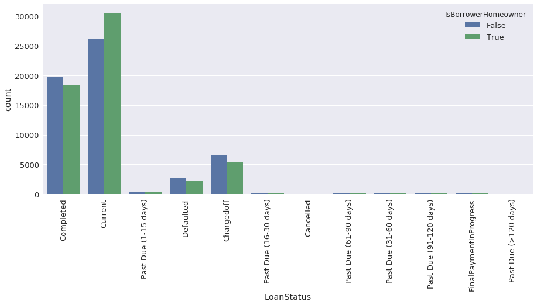

```python
plt.figure(figsize=(15,6))
sb.countplot(data = clean_loan, x = 'LoanStatus', hue = 'IsBorrowerHomeowner')
plt.xticks(rotation=90);
```

Looks like borrowers who have completed the loan payment have more people that dont have homes.Those who are currently paying off their loans have more people who are home owners.

# Relationship between home owners and employement status

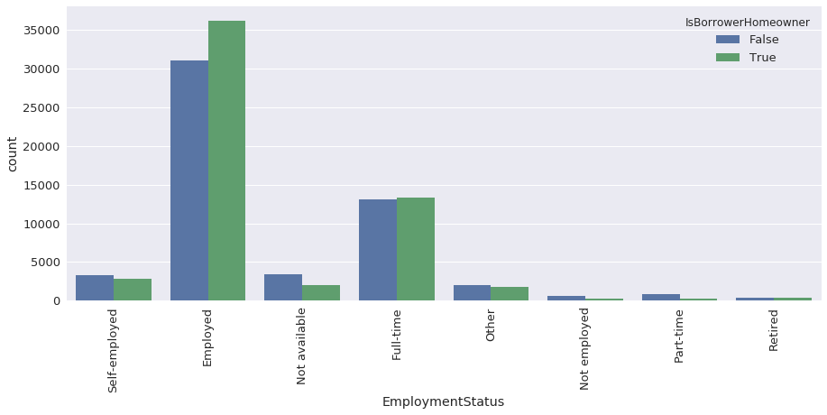

```python
plt.figure(figsize=(15,6))
sb.countplot(data = clean_loan, x = 'EmploymentStatus', hue = 'IsBorrowerHomeowner')
plt.xticks(rotation=90);
```

More employed people are home owners, more self employed people and unemployed people did not have homes.

# What is the correlation between the borrowers annual percentage rate and the borrowers interest rate?

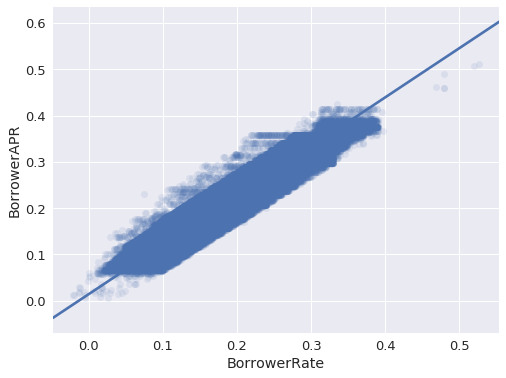

```python
#scatter plot on linear scale
plt.figure(figsize = [8, 6])
sb.regplot(data = clean_loan, x = 'BorrowerRate', y = 'BorrowerAPR',x_jitter=0.04,scatter_kws={'alpha':1/10});
```

There is a positive correlation between the borrower's interest rate and the borrower's annual interest rate.

## Does their monthly income affect the servicing of their loans?

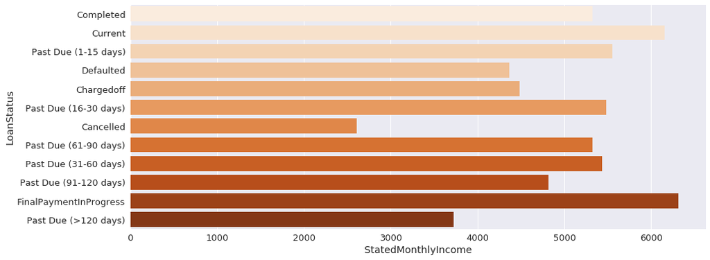

```python
plt.figure(figsize=(15,6))
sb.barplot( x = 'StatedMonthlyIncome', y = 'LoanStatus', ci=None, data=clean_loan, palette = 'Oranges');
```

Looks like borrowers who have completed their payment, in the final payment progress or currently servicing the loan earn more than those who defaulted in their payment.

# Did the borrowers employment status affect the amount they borrowed?

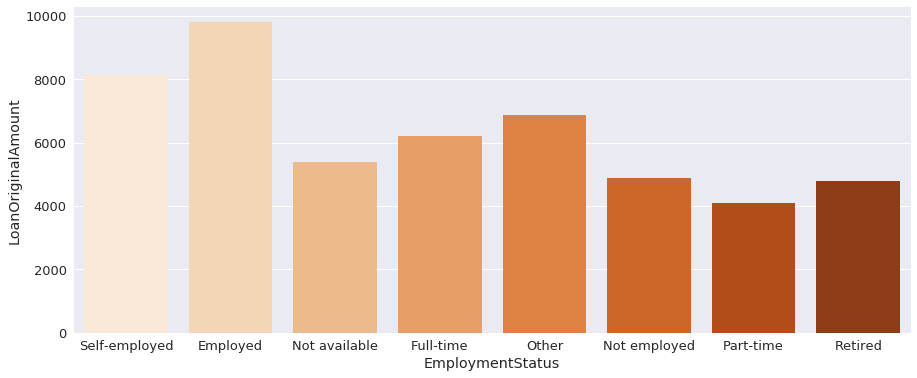

```python
plt.figure(figsize=(15,6))
sb.barplot( x = 'EmploymentStatus', y = 'LoanOriginalAmount', ci=None, data=clean_loan, palette = 'Oranges');
```

It looks like borrowers who are employed acquired larger amounts than borrowers that are not employed or retired.

### Talk about some of the relationships you observed in this part of the investigation. How did the feature(s) of interest vary with other features in the dataset?

> For the relationship between home owners and employment status, it looks like we have more people who are home owners in the employed category. For the self-employed and unemployed category, we have more people who are not home owners. Also there is positive correlation between borrower's interest rate and borrower's annual interest rate.i.e when one is increasing, the other is also increasing and vice versa. Finally,the exploration shows that people who are employed took out larger amounts.

### Did you observe any interesting relationships between the other features (not the main feature(s) of interest)?

> I thought it was interesting that the set of borrowers that have completed their loan payment had more people who were not home owners, I would have expected more of them to be home owners.

## Multivariate Exploration

# Relationship between the employment status of the borrowers ,their monthly income and whether or not their income is verifiable.

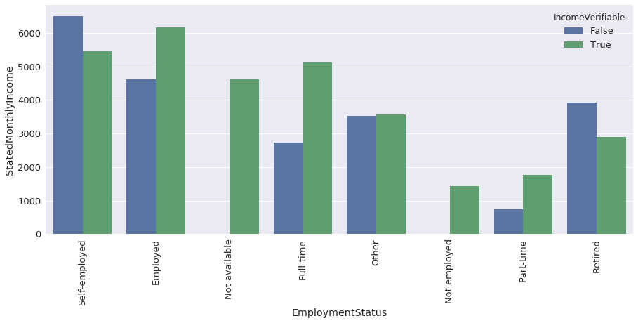

```python
#Plot a bar plot derivation
plt.figure(figsize=(15,6))
sb.barplot(data=clean_loan,x='EmploymentStatus', y='StatedMonthlyIncome', ci=None, hue='IncomeVerifiable')
plt.xticks(rotation=90);
```